# Annexe : Export du jupyter notebook au de réponce aux questions 1 & 2 de la partie 1

## Question 1 : Quelles sont les caractéristiques utilisées pour détecter les fraudes en Ethereum ?

Les caractéristiques utilisées sont les informations concernants les montants et les temps de transactions en ether et avec des tokens ERC20 ainsi qu'un flag indiquant si la transaction est une fraude et une ligne index correspondant à nombre propre à chaque ligne:

- Address: l'adresse du wallet ethereum
- Index: l'index propre à chaque ligne
- FLAG: flag indiquant s'il s'agit d'une fraude
- Avg min between sent tnx: temps moyen entre chaque transactions envoyées par ce wallet, en minute
- Avg_min_between_received_tnx: temps moyen entre chaque transactions reçues par ce wallet, en minute
- Time_Diff_between_first_and_last(Mins): différence de temps entre la première et la dernière transaction
- Sent_tnx: Nombre total de transactions envoyées
- Received_tnx: Nombre total de transactions reçues
- Number_of_Created_Contracts: Nombre total de transactions de contrat créées
- Unique_Received_From_Addresses: Nombre total d'adresses uniques à partir desquelles le compte a reçu des transactions
- Unique_Sent_To_Addresses20: Nombre total d'adresses uniques à partir desquelles le compte a envoyé des transactions
- Min_Value_Received: Valeur minimale en Ether jamais reçue
- Max_Value_Received: Valeur maximale en Ether jamais reçue
- Avg_Value_Received: Valeur moyenne en Ether jamais reçue
- Min_Val_Sent: Valeur minimale d'Ether jamais envoyée
- Max_Val_Sent: Valeur maximale d'Ether jamais envoyée
- Avg_Val_Sent: Valeur moyenne d'Ether jamais envoyée
- Min_Value_Sent_To_Contract: Valeur minimale d'Ether envoyée à un contrat
- Max_Value_Sent_To_Contract: Valeur maximale d'Ether envoyée à un contrat
- Avg_Value_Sent_To_Contract: Valeur moyenne d'Ether envoyée aux contrats
- Total_Transactions(Including_Tnx_to_Create_Contract): Nombre total de transactions (y compris celles pour créer des contrats)
- Total_Ether_Sent: Total d'Ether envoyé pour l'adresse du compte
- Total_Ether_Received: Total d'Ether reçu pour l'adresse du compte
- Total_Ether_Sent_Contracts: Total d'Ether envoyé aux adresses de contrat
- Total_Ether_Balance: Solde total d'Ether après les transactions effectuées
- Total_ERC20_Tnxs: Nombre total de transactions de transfert de jetons ERC20
- ERC20_Total_Ether_Received: Total des transactions de jetons ERC20 reçues en Ether
- ERC20_Total_Ether_Sent: Total des transactions de jetons ERC20 envoyées en Ether
- ERC20_Total_Ether_Sent_Contract: Total des transactions de transfert de jetons ERC20 vers d'autres contrats en Ether
- ERC20_Uniq_Sent_Addr: Nombre de transactions de jetons ERC20 envoyées à des adresses de compte uniques
- ERC20_Uniq_Rec_Addr: Nombre de transactions de jetons ERC20 reçues à partir d'adresses uniques
- ERC20_Uniq_Rec_Contract_Addr: Nombre de transactions de jetons ERC20 reçues à partir d'adresses de contrat uniques
- ERC20_Avg_Time_Between_Sent_Tnx: Temps moyen entre les transactions de jetons ERC20 envoyées en minutes
- ERC20_Avg_Time_Between_Rec_Tnx: Temps moyen entre les transactions de jetons ERC20 reçues en minutes
- ERC20_Avg_Time_Between_Contract_Tnx: Temps moyen entre les transactions de jetons ERC20 envoyées
- ERC20_Min_Val_Rec: Valeur minimale en Ether reçue des transactions de jetons ERC20 pour le compte
- ERC20_Max_Val_Rec: Valeur maximale en Ether reçue des transactions de jetons ERC20 pour le compte
- ERC20_Avg_Val_Rec: Valeur moyenne en Ether reçue des transactions de jetons ERC20 pour le compte
- ERC20_Min_Val_Sent: Valeur minimale en Ether envoyée des transactions de jetons ERC20 pour le compte
- ERC20_Max_Val_Sent: Valeur maximale en Ether envoyée des transactions de jetons ERC20 pour le compte
- ERC20_Avg_Val_Sent: Valeur moyenne en Ether envoyée des transactions de jetons ERC20 pour le compte
- ERC20_Uniq_Sent_Token_Name: Nombre de jetons ERC20 uniques transférés
- ERC20_Uniq_Rec_Token_Name: Nombre de jetons ERC20 uniques reçus
- ERC20_Most_Sent_Token_Type: Jeton le plus envoyé pour le compte via la transaction ERC20
- ERC20_Most_Rec_Token_Type: Jeton le plus reçu pour le compte via les transactions ERC20

## Question 2 : Implémenter une technique pour supprimer les caractéristiques corrélées

*Basé sur le travail de [CHITICARIU CRISTIAN](https://www.kaggle.com/code/chiticariucristian/fraud-detection-ethereum-transactions)*

```python
import pandas as pd
import matplotlib.pyplot as plt
import numpy as np
import seaborn as sns
```

```python
df = pd.read_csv('transaction_dataset.csv', index_col=0)
print(df.shape)
df.head()

# supprimer les deux premières colonnes (Index, Adress)
df = df.iloc[:,2:]

#Récupération de la liste des objets sous forme de dataframe
categories = df.select_dtypes('O').columns.astype('category')
```

```
(9841, 50)
```

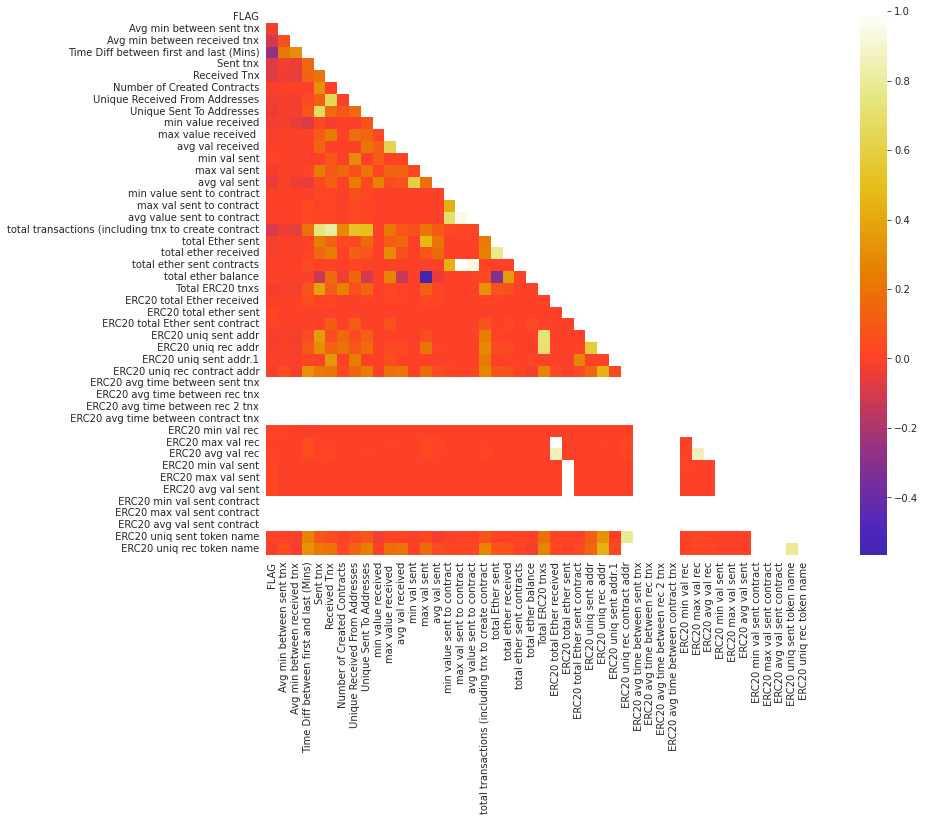

```python
numericals = df.select_dtypes(include=['float','int']).columns

corr = df.corr(numeric_only=True)

mask = np.zeros_like(corr)
mask[np.triu_indices_from(mask)]=True
with sns.axes_style('white'):
    fig, ax = plt.subplots(figsize=(18,10))
    sns.heatmap(corr,  mask=mask, annot=False, cmap='CMRmap', center=0, square=True)
```

On peut constater qu'il y a des trous dans la heatmap, ce qui rend impossible pour l'instant la suppression des lignes fortement correlées. Il faut donc les filtrer.

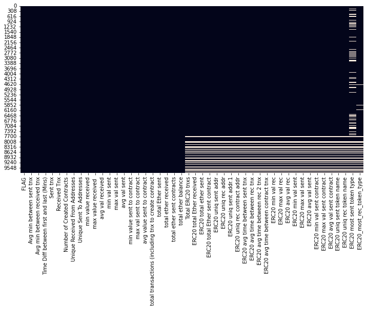

```python
# Visualize missings pattern of the dataframe
plt.figure(figsize=(12,6))
sns.heatmap(df.isnull(), cbar=False)
plt.show()
# Drop the two categorical features
df.drop(df[categories], axis=1, inplace=True)
# Replace missings of numerical variables with median
df.fillna(df.median(), inplace=True)# Replace missings of numerical variables with median
df.fillna(df.median(), inplace=True)
```

On remplace les valeurs manquantes par la médiane de la colonne correspondante

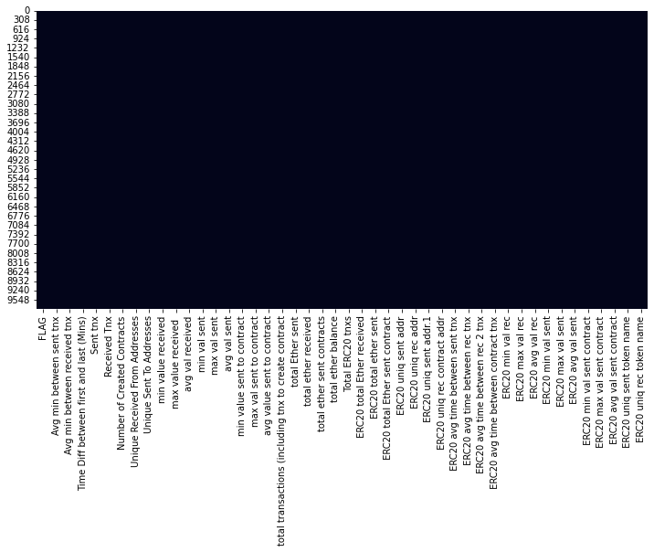

```python
#Remplacement par la médiane des valeurs de la colonne
df.fillna(df.median(), inplace=True)

plt.figure(figsize=(12,6))
sns.heatmap(df.isnull(), cbar=False)
plt.show()
```

Il n'y a plus de colonne ayant des valeurs nulles. Il faut aussi s'assurer que toutes les colonnes n'aient pas de valeurs identique pour l'ensemble des lignes, c'est à dire une variance nulle, si c'est le cas, il faut supprimer la colonne

```python
# Filtering the features with 0 variance
no_var = df.var() == 0

# Drop features with 0 variance --- these features will not help in the performance of the model
df.drop(df.var()[no_var].index, axis = 1, inplace = True)
```

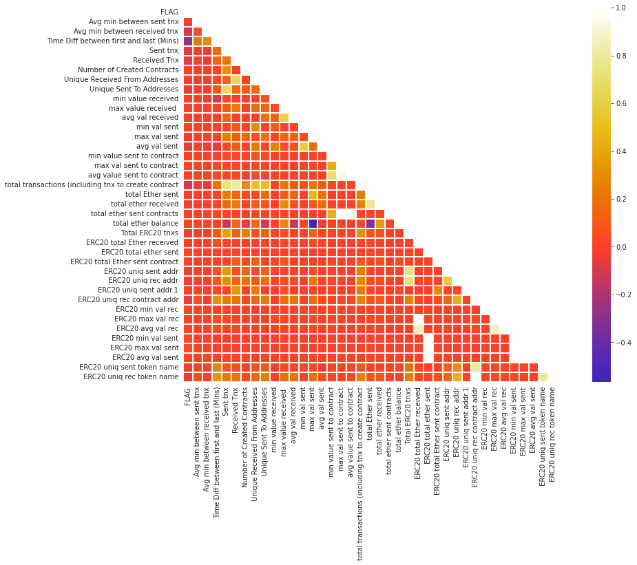

```python
corr = df.corr()

mask = np.zeros_like(corr)
mask[np.triu_indices_from(mask)]=True
with sns.axes_style('white'):
    fig, ax = plt.subplots(figsize=(18,10))
    sns.heatmap(corr,  mask=mask, annot=False, cmap='CMRmap', center=0, linewidths=0.1, square=True)
```

```python
drop = ['total transactions (including tnx to create contract', 'total ether sent contracts', 'max val sent to contract', ' ERC20 avg val rec',
        ' ERC20 avg val rec',' ERC20 max val rec', ' ERC20 min val rec', ' ERC20 uniq rec contract addr', 'max val sent', ' ERC20 avg val sent',
        ' ERC20 min val sent', ' ERC20 max val sent', ' Total ERC20 tnxs', 'avg value sent to contract', 'Unique Sent To Addresses',
        'Unique Received From Addresses', 'total ether received', ' ERC20 uniq sent token name', 'min value received', 'min val sent', ' ERC20 uniq rec addr' ]
df.drop(drop, axis=1, inplace=True)
```

On obtient la matrice de correlation suivante à la fin :

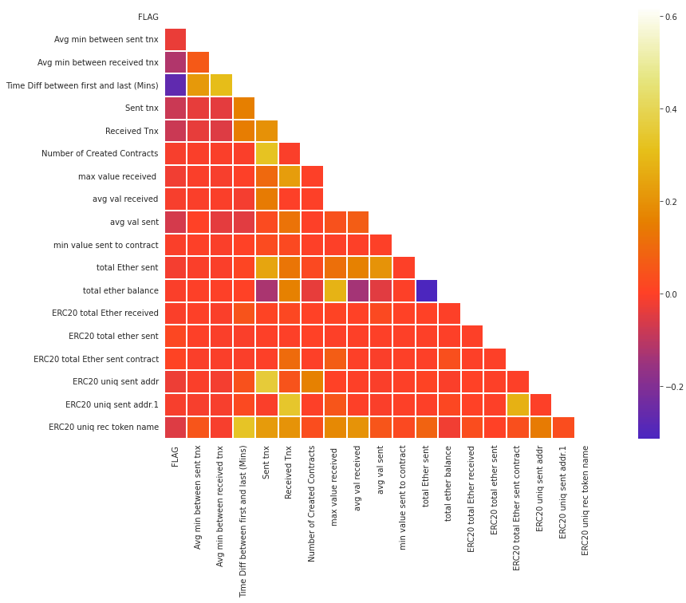

```python
corr = df.corr()

mask = np.zeros_like(corr)
mask[np.triu_indices_from(mask)]=True
with sns.axes_style('white'):
    fig, ax = plt.subplots(figsize=(18,10))
    sns.heatmap(corr,  mask=mask, annot=False, cmap='CMRmap', center=0, linewidths=0.1, square=True)
```